# Class 11: Responses to Political Violence

State responses: Policies

[Dr. Michael C. Zeller](https://michaelzeller.de)

# Opening notes

[Open Sticker](https://tenor.com/view/open-gif-14209777)from [Open Stickers](https://tenor.com/search/open-stickers)

- **short synopsis** for final essay due **Friday (17 January)** (send to me via email)

# State policy responses

- What options/possibilities are there
- One policy example
- deradicalisation programmes
  - Membrives and Alonso (2022)

[They Can Reform Their Policies Make Changes GIF](https://tenor.com/view/they-can-reform-their-policies-make-changes-address-a-problem-improvement-amendment-gif-13864082)from [They Can Reform Their Policies GIFs](https://tenor.com/search/they+can+reform+their+policies-gifs)

## Starting question

**What *policies* can states apply to address (potential) political violence? Can we categorise them somehow?**

## One policy example

Does anyone recognise this site?

[figure not shown]

## One policy example

[figure not shown]

- Valley of the Fallen (incl., Catholic basilica), outside Madrid
- monument constructed under Franco, using forced/convict labour
- burial place for Franco (exhumed 24.10.2019) and Primo de Rivera (exhumed 23.4.2023)
- *Ley de Memoria Histórica*: recognises and broadens “the rights and establishes measures in favour of those who suffered persecution or violence during the civil war and the dictatorship.”

## Deradicalisation programmes

- definition: initiatives to help individuals stop extremist behaviour and abandon extremist beliefs
- common elements:
  1. mixed programme elements
  2. *credible* deradicalisation
  3. post-treatment follow-up
  4. create commitments (to family, work, etc.)
  5. material inducement (but not relying on this)

## Deradicalisation programme - Indonesia

[video not shown]

## Membrives and Alonso (2022, 19) - the aim of derad./exit programmes

> The [Radicalization Awareness Network](https://home-affairs.ec.europa.eu/networks/radicalisation-awareness-network-ran_en) evaluation of exit programs understands that “success for exit programs usually consists of disengagement (leaving a radical environment and violent behaviour), deradicalization (leaving a radical ideology), functional integration (such as housing, employment and health care) and social reintegration (family, friends, community) in the long term.

## Membrives and Alonso (2022) - research approach

- RQ: what are the challenges of intervening with juvenile offenders involved in terrorism?
- cases: five radicalized minors from Spain who were convicted of membership of a jihadist terrorist organisation, now engaged in derad. programmes
- data: semi-structured interviews
- four stages of intervention
  1. evaluation of the youths’ risks and needs
  2. hypothesis formulation of each individual case
  3. design and implementation of objectives, actions, and activities
  4. final evaluation

## Membrives and Alonso (2022) - initial risk evaluation

what do you think of these ‘factors’ for assessing risk?

| Factor | Nadia | Oscar | Dafya | Thamir | Caleb |
| --- | --- | --- | --- | --- | --- |
| 1. Past and present offenses and sentences | low | low | low | low | low |
| 2. educational guidelines in family environment | moderate | moderate | low | moderate | moderate |
| 3. formal education/ employment | high | moderate | moderate | low | low |
| 4. relationship with peer group | moderate | high | low | high | high |
| 5. Substance misuse | low | moderate | low | low* | low* |
| 6. leisure/hobbies | high | high | moderate | high | high |
| 7. Personality/ behavior | moderate | moderate | moderate | moderate | moderate |
| 8. Attitudes, values, and beliefs | moderate | high | moderate | high | high |
| General risk level | 21 | 22 | 5 | 19 | 18 |
|  | from moderate (9–22) to very high | from moderate (9–22) to very high | from low (0–8) to moderate | from moderate (9–22) to very high | from moderate (9–22) to very high |

## Membrives and Alonso (2022) - activities

why these activities for a derad. programme? what’s the reasoning? do you think it would be effective?

| Area | Activity | Nadia | Oscar | Dafya | Thamir | Caleb |
| --- | --- | --- | --- | --- | --- | --- |
| formative | School classroom at the Center | X | X | X | X | X |
| formative | School support and encouragement for reading |  |  | X |  | X |
| formative | Vocational training |  |  | X |  |  |
| Pre-work | Book binding | X | X |  | X |  |
| Pre-work | restoration | X | X |  |  | X |
| Pre-work | pottery | X |  |  |  |  |
| Pre-work | modeling, sculpture, decoration |  |  | X |  | X |
| Pre-work | handcrafted wood turning |  |  |  | X | X |
| Personal development and social competence | Central educational and therapeutic treatment Program for Young offenders | X | X | X | X | X |
| Personal development and social competence | Program on Personal development and Social Competence | X | X | X | X | X |
| Personal development and social competence | Program on Personal development and Civic-ethic education | X | X | X | X | X |
| Personal development and social competence | Program on Preparation for an independent life |  | X |  |  |  |
| Personal development and social competence | Workshop on equal opportunities | X |  | X | X |  |
| occupational workshop | dance workshop | X |  |  |  |  |
| occupational workshop | Painting on canvas, decoration, models | X | X | X | X | X |
| leisure and free time | Sports | X | X | X | X | X |
| leisure and free time | Video-forum | X | X | X | X | X |
| leisure and free time | Group leisure | X | X | X | X | X |
| leisure and free time | individual leisure | X | X | X | X | X |

## Membrives and Alonso (2022) - activities rated according to

**activities rated according to**…

1. **Implementation**: efforts have been made by the practitioners who remain awaiting the assimilation and response by the minor;
2. **Development**: the minor has assimilated ideas and has begun to respond making some efforts;
3. **Reinforcement**: the minor has made considerable progress, but it is necessary to continue supervising him/her;
4. **Finalized**: the minor has met the objective;
5. **Interrupted**: it has not been possible to work on the objective and/or activity.

## Membrives and Alonso (2022) - takeaways

1. Traditional objectives of criminal justice must give way to rehabilitation and restorative justice objectives when dealing with minors.
   - **do you agree or disagree? This is an ongoing debate in public policy**
2. The Spanish judicial framework provides the framework for the judicial response against offences committed by youths in Spain, with the guiding principles of any intervention being its sanctioning-educational nature and the superior interest of the minor.

# Poll: state policies

[figure not shown]

Take the survey at **https://forms.gle/WskY6kmGLEjXvo586**

- policy to pacify ethnic/sectarian conflict?
- de-radicalisation more successful than punishment?
- criminalising hate speech and incitement?
- most important support during *disengagement*?
- effective policy measures preventing radicalisation?
- participation in de-radicalisation programmes be mandatory?
- should states fund religious or ideological mentors?

Questions about groups: (1) State response primarily driven by security concerns? (2) State mostly uses policy-based responses? (3) State has a coherent long-term strategy toward group? (4) The group is primarily treated as…? (5) State has engaged group in negotiation? (6) Foreign gov(s). shape state response toward group?

[interactive chart not shown]

policy approach to pacify ethnic/sectarian conflict?

[interactive chart not shown]

## Poll results: state policy responses

de-radicalisation programmes more successful than punishment?

[interactive chart not shown]

most important support during *disengagement*?

[interactive chart not shown]

## Poll results: state policy responses

effective policy measures preventing radicalisation?

[interactive chart not shown]

criminalising hate speech and incitement?

[interactive chart not shown]

## Poll results: state policy responses

participation in de-radicalisation programmes be mandatory?

[interactive chart not shown]

should states fund religious or ideological mentors?

[interactive chart not shown]

## Group responses

The group is primarily treated as a:

[interactive chart not shown]

## Group responses

State has a coherent long-term strategy toward this group?

[interactive chart not shown]

## Group responses

State response primarily driven by security concerns?

[interactive chart not shown]

State mostly uses policy-based responses?

[interactive chart not shown]

## Group responses

State has engaged group in negotiation?

[interactive chart not shown]

Foreign gov(s). shape state response?

[interactive chart not shown]

# Criminal justice responses

- criminal justice responses to political violence
- Koehler (2019) - Violence and Terrorism from the Far-Right: Policy Options to Counter an Elusive Threat

[Remember The Titans Cruel And Unusual Punishment GIF](https://tenor.com/view/remember-the-titans-cruel-and-unusual-punishment-earl-c-poitier-gif-15710318)from [Remember The Titans GIFs](https://tenor.com/search/remember+the+titans-gifs)

## criminal justice responses to political violence - an example (Taylor and Suliman 2021)

- 21-years-old British man, Ben John, with neo-Nazi sympathies
- collected extremist documents (including a book that contains bomb-making instructions, illegal in the UK) on computer
  - possessing information likely to be useful for preparing an act of terrorism, punishable by up to 15 years in prison under Section 58 of UK’s Terrorism Act

recommended sentencing? what do you think? (keeping in mind British judges have lots of leeway with sentencing)

- sentenced by judge to read works of great literature by Jane Austen, William Shakespeare, Thomas Hardy and Charles Dickens
- appeals court overturns ruling, sentenced to two years in prison

## Koehler (2019) - EU context

**Comparing right-wing extremist terrorism to other forms**

> Even though the number of arrests related to right-wing extremist terrorism within the European Union almost doubled to **20 in 2017 from 12 in 2016**, it pales in comparison to other forms of political violence, at least in terms of numbers (e.g. **705 jihadists in 2017**).

## Koehler (2019) - focusing in on Germany

[interactive chart not shown]

RWE explosives & arson crimes (bars); all RWE violent crimes (line)

Looking at … explosives attacks or arson, crimes usually but not always (legally) framed as terrorism, statistics from Germany indicate a surge during the so-called “refugee crisis” between 2015 and 2016. …

## Koehler (2019) - focusing in on Germany, homicides

Recognised by BRD vs. identified by [Amadeu Antonio Stiftung](https://www.amadeu-antonio-stiftung.de/todesopfer-rechter-gewalt/)

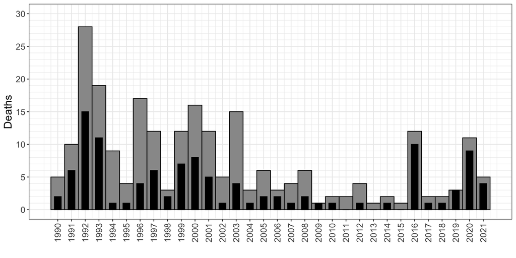

## Koehler (2019) - focusing in on Germany, homicides

```r
library(tmap)
library(tidyverse)
library(sf)
library(rnaturalearth)
library(gganimate)
library(gifski)

dfALLgrouped <- dfALL %>%
  group_by(YEAR)

dfALLgrouped <- as.data.frame(dfALLgrouped)

dfALLgrouped$Latitude <- dfALLgrouped$LAT
dfALLgrouped$Longitude <- dfALLgrouped$LON

dfALLgrouped$LATjit <- jitter(dfALLgrouped$LAT, factor = 300)
dfALLgrouped$LONjit <- jitter(dfALLgrouped$LON, factor = 300)

dfALLgrouped_sf <- dfALLgrouped %>% drop_na(LAT)

dfALLgrouped_sf <- dfALLgrouped_sf %>%
  st_as_sf(
    coords = c("LONjit", "LATjit"),
    crs = st_crs("EPSG:32632") # CRS for Germany
  )

DE = ne_states(returnclass = "sf") |>
  filter(admin == "Germany")

st_crs(dfALLgrouped_sf) <- st_crs(DE)

fr_hom_anim <- tm_shape(DE)+
  tm_polygons(fill="gold", col="darkolivegreen")+
  tm_shape(dfALLgrouped_sf)+
  tm_bubbles(shape=21,
             size=5,
             col="CATEGORY",
             palette = c("Official" = "red","Unofficial" = "blue"),
             scale=8,
             alpha=0.5,
             border.col="black")+
  tm_facets(pages="YEAR")+
  tm_layout(legend.show = FALSE,
            panel.label.size = 4,
            panel.label.color = 'black',
            panel.label.bg.color = 'grey',
            panel.label.height = 3,
            legend.text.size = 1.5)
tmap_animation(
  fr_hom_anim,
  filename = "fr_hom_anim.gif",
  delay = 50,
  width = 1200,
  height = 1200
)
```

o: recognised by BRD  
o: identified by Amadeu Antonio Stiftung

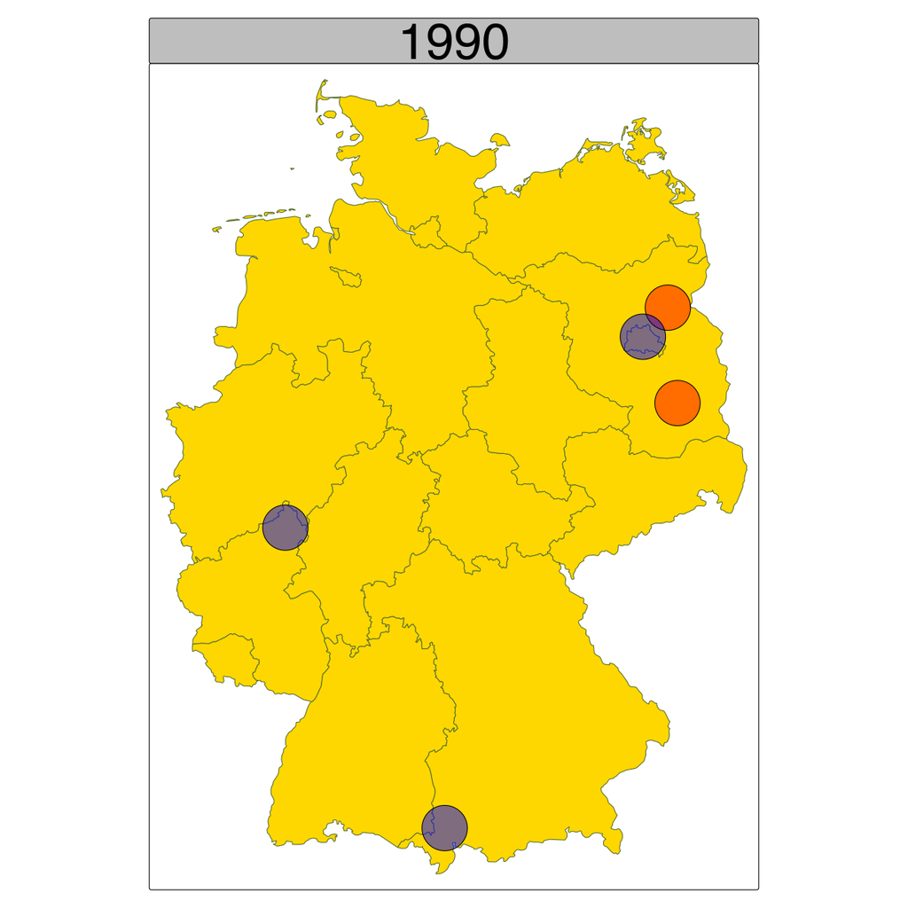

## Koehler (2019) - focusing in on Germany, homicides

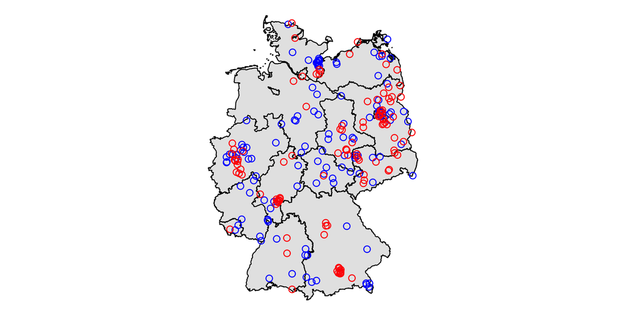

o: officially recognised by BRD  
o: identified by Amadeu Antonio Stiftung

## Koehler (2019) - focusing in on Germany, law enforcement

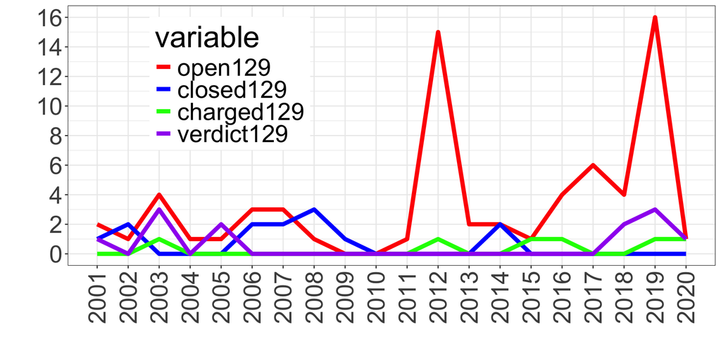

*Ermittlungsverfahren*/opened 129 case  
closed/discontinued 129 case  
charges in 129 case  
verdict/conviction in 129 case  
compare: jihadist terrorism in 2017: 952 opened cases, 460 closed

- §129: forming or membership in criminal or terrorist org.
- more terror investigations paralleling spikes in right-wing extremist violence
  - 2012 (15) spike, reaction to NSU
  - i.e., triggered by political and popular pressure
- “*However, even if keeping in mind that one group could have been responsible for more than one arson or explosive attack, the number of new investigations still falls short of the overall level of severe violence (four and six new investigations in 2016 and 2017).*”

## debate raised by Koehler (2019): hate crime - terrorism

- hate crimes: “*a criminal act that is motivated by a bias toward the victim or victims real or perceived identity group*”, may include the desire to “*terrorize a broader group*”

## debate raised by Koehler (2019): hate crime - terrorism

1. RWE hate crimes - terrorism: **close cousins**
   - “the target of an offense is selected because of his or her group identity, not because of his or her individual behaviour, and because the effect of both is to wreak terror on a greater number of people than those directly affected by violence”
2. RWE hate crimes - terrorism: **distant relatives**
   - terrorism: lots of planning, usually; actively seek publicity
   - hate crimes: more spontaneous, usually; seldom seek publicity
3. RWE violence can be **both**
   - depending on the degree to which it pursues political and social objectives (prerequisite for terrorism—not for hate crimes)

what does your expertise tell you? what is your position?

## Koehler (2019): selected recommendations

- Avoid double standards between forms of political violence
- allocate adequate resources to counter RWE
- appropriate judicial responses (‘quick and efficient’)
- increase funding for research on FR violence and terrorism
- acknowledge relationship between hate crimes and terrorism
  - reporting mechanisms about right-wing terrorism should not only be based on legal prosecutions and convictions using the ‘*terrorism*’ label, but also consider psychological effects on the target group of violent acts and specific attack forms used.
- expand EXIT programmes for RWE

what do you make of these recommendations (or others)?

## Democracy-building policy example

[Demokratie leben!](https://www.demokratie-leben.de/en/programme) - ‘practising and maintaining democratic culture’

- finances projects all over Germany that develop and trial new ideas and innovative approaches in promoting democracy, encouraging diversity, and preventing extremism.

[video not shown]

# Snapshot: stopping ethnic violence

- Varshney (2001): Hindu-Muslim violence in India (urban and locally concentrated)—breakouts of violence in some cities (e.g., Aligarh) and not others (e.g., Calicut)—why?
  - Calicut:
    - ‘peace committees’ work across communities, quash rumours
    - Hindus and Muslims: 84% visit each other regularly; 83% eat together; 90% children play together
  - Aligarh:
    - peace committees tend to be *intrareligious*, not interreligious
    - Hindus and Muslims: 60% visit each other regularly; 54% eat together; 42% children play together

## Snapshot: stopping ethnic violence

- Varshney (2001): Hindu-Muslim violence in India (urban and locally concentrated)—breakouts of violence in some cities (e.g., Aligarh) and not others (e.g., Calicut)—why?

> The preexisting local networks of civic engagement between the two communities stand out as the single most important proximate explanation for the difference between peace and violence.

This argument, it should be clarified, is probabilistic, not lawlike.

- Darby (1986): sectarian violence in Belfast communities (Kileen/Banduff, Upper Ashbourne Estates) and absence (Dunville)
  - Dunville: non-segregated service, sport, and parent clubs

# Any feedback for this class?

Anonymous feedback here: https://forms.gle/NfF1pCfYMbkAT3WP6

Alternatively, please send me an email: m.zeller@lmu.de

Questions about groups next week: (1) The state infiltrated or monitored the group? (2) Repression is a central to the state’s strategy? (3) Repression against group viewed as legitimate? (4) Repression reduced group’s operational capacity? (5) State cooperates internationally against group?

## References

Darby, John. 1986. *Intimidation and the Control of Conflict in Northern Ireland*. Syracuse, NY: Syracuse University Press.

Koehler, Daniel. 2019. “Violence and Terrorism from the Far-Right: Policy Options to Counter an Elusive Threat.” Policy {{Brief}} February. The Hague: International Centre for Counter-Terrorism. https://www.jstor.org/stable/pdf/resrep19617.pdf.

Membrives, María Teresa García, and Rogelio Alonso. 2022. “Countering Violent Extremism in Spain: Analyzing the Intervention with Young Jihadi Convicted of Membership of a Terrorist Organization.” *Studies in Conflict & Terrorism*, November, 1–33. https://doi.org/10.1080/1057610X.2022.2143741.

Taylor, Adam, and Adela Suliman. 2021. “British White Supremacist , Initially Sentenced to Read Austen and Dickens , Imprisoned for Two Years.” *The Washington Post*, January.

Varshney, Ashutosh. 2001. “Ethnic Conflict and Civil Society: India and Beyond.” *World Politics* 53 (3): 362–98.